# Phase 4 Path-Selection Diagnostics for Path-Divided-Difference Graph Trend Filtering

## 1 Purpose

This report is the Phase 4 diagnostic layer for the experimental path-divided-difference graph trend-filtering operator.

The operator begins with canonical path rows

$$\mathcal P_r(G)=\overrightarrow{\mathcal P}_r(G)/{\sim},$$

where $\sim$ identifies a path with its reverse. The open modeling question is whether every non-duplicate simple path should become a penalty row, or whether a smaller row set should be selected to avoid over-constraining branch points and dense data-derived graphs.

The report compares four row-selection rules for $r=2$, corresponding to order $k=1$ trend filtering:

- `all`: all canonical simple length-2 paths;
- `branch.continuation`: paths whose internal vertices are not graph-theoretic branch points;
- `overlap.thinned`: a greedy low-redundancy subset based on the path-overlap graph;
- `coverage.greedy`: a greedy subset that prioritizes vertex and edge coverage.

This is deliberately a development report, not a public API proposal.

## 2 Diagnostic Inputs

```r
summaries <- diagnostics$summaries
vertex.coverage <- diagnostics$vertex.coverage
path.tables <- diagnostics$path.tables

data.frame(
  generated_at = diagnostics$generated_at,
  n_graphs = length(unique(summaries$graph)),
  n_selection_rules = length(unique(summaries$selection)),
  n_diagnostic_rows = nrow(summaries),
  n_error_rows = sum(summaries$status != "ok")
)
```

```
##              generated_at n_graphs n_selection_rules n_diagnostic_rows
## 1 2026-05-16 21:35:00 EDT        6                 4                24
##   n_error_rows
## 1            1
```

The toy graphs are intentionally small:

- `path7`: ordinary seven-vertex path graph;
- `star3_arm2`: three-arm star with two vertices per arm;
- `star3_arm4`: longer three-arm star;
- `cycle8`: small cycle;
- `grid3x3`: small two-dimensional grid;
- `sknn1d12`: symmetric 3-nearest-neighbor graph from 12 one-dimensional samples.

## 3 Summary Table

```r
summaries[order(summaries$graph, summaries$selection), ]
```

```
##         graph           selection n.vertices n.edges order difference.order
## 13     cycle8                 all          8       8     1                2
## 14     cycle8 branch.continuation          8       8     1                2
## 16     cycle8     coverage.greedy          8       8     1                2
## 15     cycle8     overlap.thinned          8       8     1                2
## 17    grid3x3                 all          9      12     1                2
## 18    grid3x3 branch.continuation          9      12     1                2
## 20    grid3x3     coverage.greedy          9      12     1                2
## 19    grid3x3     overlap.thinned          9      12     1                2
## 1       path7                 all          7       6     1                2
## 2       path7 branch.continuation          7       6     1                2
## 4       path7     coverage.greedy          7       6     1                2
## 3       path7     overlap.thinned          7       6     1                2
## 21   sknn1d12                 all         12      20     1                2
## 22   sknn1d12 branch.continuation         12      20     1                2
```

[output cut: 110 more lines]

## 4 Row Counts

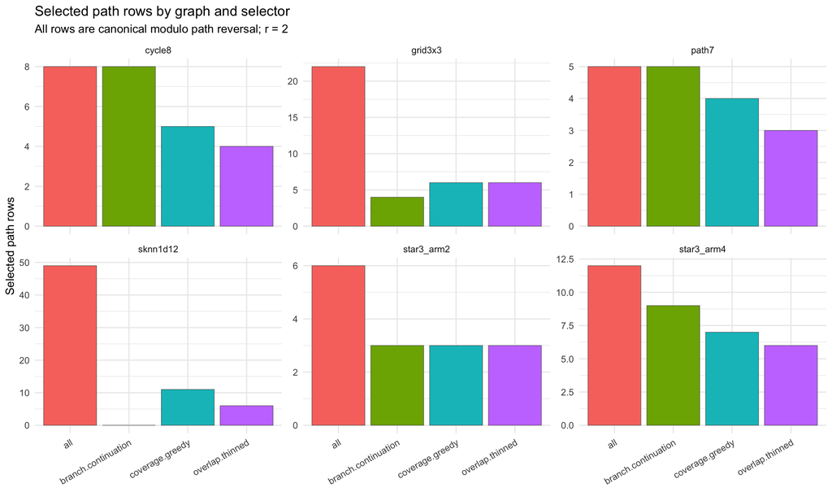

```r
ggplot(summaries, aes(x = selection, y = selected.rows, fill = selection)) +
  geom_col(color = "gray35", linewidth = 0.2) +
  facet_wrap(~ graph, scales = "free_y") +
  labs(
    title = "Selected path rows by graph and selector",
    subtitle = "All rows are canonical modulo path reversal; r = 2",
    x = NULL,
    y = "Selected path rows"
  ) +
  theme_minimal(base_size = 11) +
  theme(legend.position = "none", axis.text.x = element_text(angle = 30, hjust = 1))
```

`branch.continuation` is intentionally restrictive. On tree-like stars this captures arm-continuation semantics. On the kNN graph it can produce no rows, because high graph degree is not the same as a geometric branch point.

## 5 Nullity

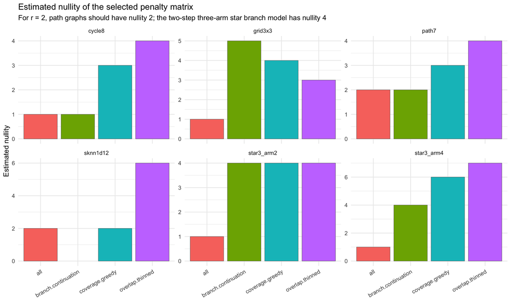

```r
ok.summary <- subset(summaries, status == "ok")

ggplot(ok.summary, aes(x = selection, y = nullity, fill = selection)) +
  geom_col(color = "gray35", linewidth = 0.2) +
  facet_wrap(~ graph, scales = "free_y") +
  labs(
    title = "Estimated nullity of the selected penalty matrix",
    subtitle = "For r = 2, path graphs should have nullity 2; the two-step three-arm star branch model has nullity 4",
    x = NULL,
    y = "Estimated nullity"
  ) +
  theme_minimal(base_size = 11) +
  theme(legend.position = "none", axis.text.x = element_text(angle = 30, hjust = 1))
```

The star examples are the key sanity check. `all` includes cross-arm paths and pushes the null space toward constants. `branch.continuation` preserves independent arm slopes. The two experimental selectors recover similar behavior on `star3_arm2` because their coverage objectives naturally choose the three arm-continuation rows.

## 6 Coverage

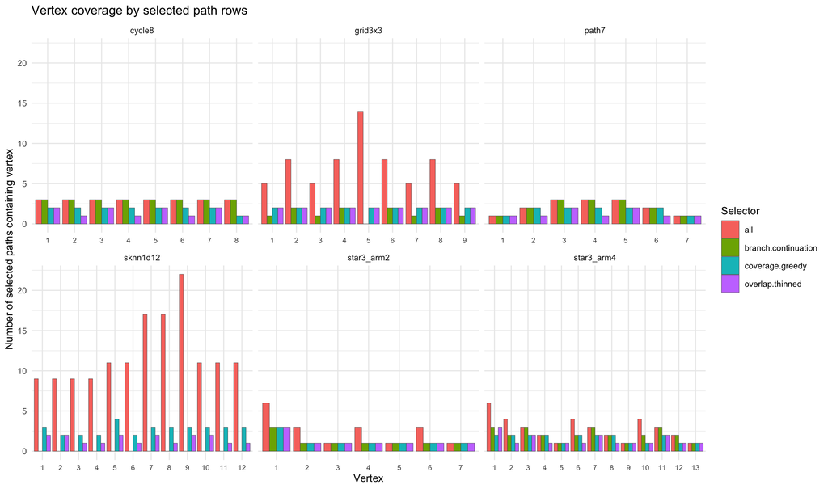

```r
ggplot(vertex.coverage, aes(x = factor(vertex), y = coverage, fill = selection)) +
  geom_col(position = "dodge", color = "gray35", linewidth = 0.15) +
  facet_wrap(~ graph, scales = "free_x") +
  labs(
    title = "Vertex coverage by selected path rows",
    x = "Vertex",
    y = "Number of selected paths containing vertex",
    fill = "Selector"
  ) +
  theme_minimal(base_size = 10) +
  theme(axis.text.x = element_text(size = 7))
```

Coverage is not itself the goal, but it is a useful guardrail. A selector that gets the desired nullity by dropping entire regions of the graph is not a good operator design.

## 7 Path-Overlap Graph Diagnostics

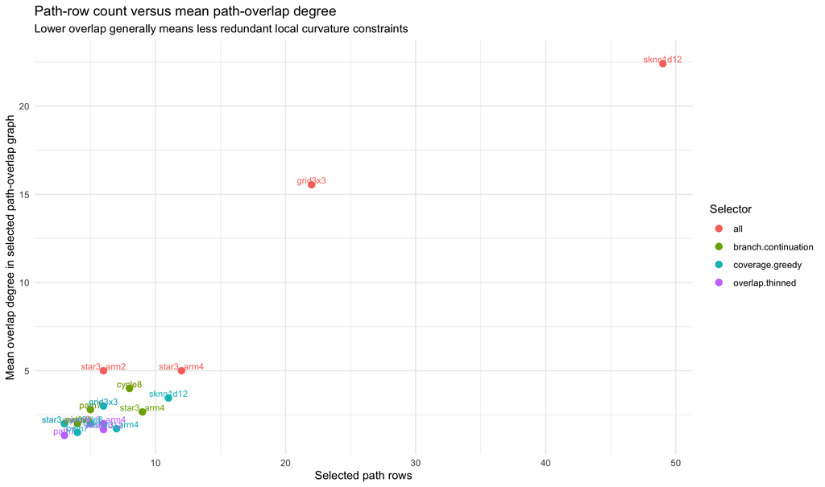

```r
ggplot(ok.summary,
       aes(x = selected.rows, y = mean.path.overlap.degree, color = selection)) +
  geom_point(size = 2.7) +
  geom_text(aes(label = graph), nudge_y = 0.25, size = 3, show.legend = FALSE) +
  labs(
    title = "Path-row count versus mean path-overlap degree",
    subtitle = "Lower overlap generally means less redundant local curvature constraints",
    x = "Selected path rows",
    y = "Mean overlap degree in selected path-overlap graph",
    color = "Selector"
  ) +
  theme_minimal(base_size = 11)
```

The overlap-thinning rule is a first attempt to select a sparse epsilon-net-like subset of path rows. The current implementation is intentionally simple: it prefers low-overlap paths and then repairs uncovered vertices. Its value here is diagnostic, not final.

## 8 Representative Path Rows

```r
sample.paths <- do.call(rbind, lapply(split(path.tables, paste(path.tables$graph, path.tables$selection)), function(tab) {
  utils::head(tab[, c("graph", "selection", "row", "vertices", "metric.length", "row.weight")], 8)
}))
rownames(sample.paths) <- NULL
sample.paths
```

```
##          graph           selection row vertices metric.length row.weight
## 1       cycle8                 all   1    1-2-3    2.00000000          1
## 2       cycle8                 all   2    1-8-7    2.00000000          1
## 3       cycle8                 all   3    2-1-8    2.00000000          1
## 4       cycle8                 all   4    2-3-4    2.00000000          1
## 5       cycle8                 all   5    3-4-5    2.00000000          1
## 6       cycle8                 all   6    4-5-6    2.00000000          1
## 7       cycle8                 all   7    5-6-7    2.00000000          1
## 8       cycle8                 all   8    6-7-8    2.00000000          1
## 9       cycle8 branch.continuation   1    1-2-3    2.00000000          1
## 10      cycle8 branch.continuation   2    1-8-7    2.00000000          1
## 11      cycle8 branch.continuation   3    2-1-8    2.00000000          1
## 12      cycle8 branch.continuation   4    2-3-4    2.00000000          1
## 13      cycle8 branch.continuation   5    3-4-5    2.00000000          1
## 14      cycle8 branch.continuation   6    4-5-6    2.00000000          1
```

[output cut: 118 more lines]

## 9 Failed or Empty Selections

```r
errors <- subset(summaries, status != "ok")
if (nrow(errors) == 0L) {
  data.frame(message = "No failed selections")
} else {
  errors[, c("graph", "selection", "message")]
}
```

```
##       graph           selection
## 22 sknn1d12 branch.continuation
##                                                         message
## 22 No length-2 paths are available for path.divided.difference.
```

The `sknn1d12` failure for `branch.continuation`, if present, is expected and important. It demonstrates why graph degree is not a reliable branch detector in data-derived kNN graphs.

## 10 Preliminary Conclusions

1. Reversal canonicalization and row selection are separate operations. Reversal canonicalization removes duplicate absolute-value rows; row selection decides which non-duplicate paths define smoothness.
2. `branch.continuation` is a useful tree/star semantics test, but it is not suitable as a default for kNN graphs.
3. `all.simple` is the cleanest mathematical baseline, but on branched graphs it adds cross-arm paths and can shrink the null space aggressively.
4. `overlap.thinned` and `coverage.greedy` are promising as diagnostic selectors because they keep graph coverage while reducing redundant path constraints.
5. The next implementation decision should not be made from nullity alone. We should evaluate selected-row operators in regression benchmarks and inspect whether the chosen rows preserve known branchwise polynomial signals.